# CellAssign: Annotating Rhabdomyosarcoma with combined marker gene sets

This notebook dives deeper into using `CellAssign` with marker gene sets derived from the [`PanglaoDB` database](https://panglaodb.se/index.html). Previously we had compared using marker gene sets from a single organ or tissue type using two different databases, `PanglaoDB` or `CellMarker2.0`. We liked the organization of `PanglaoDB`, other than the missing cell ontology IDs, so want to see how `CellAssign` performs when using marker gene sets obtained by combining cell types across organs.

Here we run `CellAssign` using two different gene sets and compare the results to the previous `CellAssign` results using only cell types found in the muscle/connective tissue and to the submitter annotations.

- `combined` refers to a reference gene set that contains all cell types found in muscle, connective tissue, and the immune system.
- `custom` refers to a reference gene set that contains all cell types found in muscle and connective tissue and only Monocytes from the immune system. This is because the only overlap between the submitter annotations and the cells in the immune system found in `PanglaoDB` are Monocytes.
- `muscle_only` refers to a reference gene set that contains only cell types found in muscle and connective tissue. The predictions from using this reference gene set were obtained by running `CellAssign` in the `cell-assign-sarcoma.Rmd` notebook.

**Note:** Running this notebook requires you to download the `<library_id>_processed_celltype.rds` file for the library that you would like to process from `s3://sc-data-integration/scpca/celltype_sce`. This file should be saved in `data/<sample_id>`.

## Set Up

```r
library(SingleCellExperiment)
library(ggplot2)

# source helper functions
function_file <- file.path("..", "utils", "cellassign-helper-functions.R")
source(function_file)
```

```r
# Set up paths

# build path to annotated sce file
processed_data_dir <-file.path("..", "data")
processed_sce_file <- glue::glue("{params$library_id}_processed_celltype.rds")
local_processed_sce_path <- file.path(processed_data_dir, params$sample_id, processed_sce_file)

# anndata output
anndata_dir <- file.path("..", "data", "anndata")
anndata_file <- glue::glue("{params$library_id}_anndata.hdf5")
anndata_file <- file.path(anndata_dir, anndata_file)

# reference files for cell marker
ref_dir <- file.path("..", "references")
panglao_file <- file.path(ref_dir, "PanglaoDB_markers_27_Mar_2020.tsv")

# matrix files
panglao_comb_mtx_file <- file.path(ref_dir, "panglao_combined_mtx.csv")
panglao_custom_mtx_file <- file.path(ref_dir, "panglao_custom_mtx.csv")
panglao_muscle_only_mtx_file <- file.path(ref_dir, "panglao_connective_tissue_mtx.csv")

# predictions output
cellassign_outs_dir <- "cellassign_results"

# cellassign predictions
combined_prediction_file <- file.path(
  cellassign_outs_dir,
  glue::glue("{params$library_id}_panglao_combined.tsv")
)
muscle_only_prediction_file <- file.path(
  cellassign_outs_dir,
  glue::glue("{params$library_id}_panglao_connective_tissue.tsv")
)
custom_prediction_file <- file.path(
  cellassign_outs_dir,
  glue::glue("{params$library_id}_panglao_custom.tsv")
)
```

```r
# read in annotated sce
processed_sce <- readr::read_rds(local_processed_sce_path)
```

```r
# write out anndata
scpcaTools::sce_to_anndata(processed_sce, anndata_file = anndata_file)
```

```
miQC model cannot be converted between SCE and AnnData.
```

```
ℹ Using the 'counts' assay as the X matrix
```

## Prep marker gene sets for CellAssign

```r
# read in panglao db
panglao_df <- readr::read_tsv(panglao_file)
```

```r
# grab all muscle related organs + all immune
panglao_tissue_immune_combined <- panglao_df |>
  dplyr::filter(organ %in% c("Connective tissue", "Smooth muscle", "Skeletal muscle", "Immune system"))

panglao_tissue_immune_combined |>
  dplyr::count(`cell type`, `organ`)
```

| cell type | organ | n |
| --- | --- | --- |
| Adipocyte progenitor cells | Connective tissue | 23 |
| Adipocytes | Connective tissue | 120 |
| Airway smooth muscle cells | Smooth muscle | 4 |
| B cells | Immune system | 110 |
| B cells memory | Immune system | 66 |
| B cells naive | Immune system | 69 |
| Basophils | Immune system | 82 |
| Chondrocytes | Connective tissue | 52 |
| Dendritic cells | Immune system | 133 |
| Eosinophils | Immune system | 30 |

[output cut: 29 more lines]

```r
# grab all muscle related organs + monocytes only
custom_marker_genes <- panglao_df |>
  dplyr::filter(organ %in% c("Connective tissue", "Smooth muscle", "Skeletal muscle") |
                `cell type` == "Monocytes")

custom_marker_genes |>
  dplyr::count(`cell type`, `organ`)
```

| cell type | organ | n |
| --- | --- | --- |
| Adipocyte progenitor cells | Connective tissue | 23 |
| Adipocytes | Connective tissue | 120 |
| Airway smooth muscle cells | Smooth muscle | 4 |
| Chondrocytes | Connective tissue | 52 |
| Fibroblasts | Connective tissue | 179 |
| Monocytes | Immune system | 102 |
| Myoblasts | Skeletal muscle | 33 |
| Myocytes | Skeletal muscle | 90 |
| Myoepithelial cells | Smooth muscle | 26 |
| Myofibroblasts | Smooth muscle | 9 |

[output cut: 5 more lines]

```r
# create rowdata df
rowdata_df <- rowData(processed_sce) |>
  as.data.frame() |>
  tibble::rownames_to_column("ensembl_id") |>
  dplyr::select(ensembl_id, gene_symbol)

# create list of marker gene sets
all_marker_genes <- list(panglao_tissue_immune_combined,
                         custom_marker_genes)
names(all_marker_genes) <- c("combined", "custom")

# get binary mtx for combined tissues
binary_matrix_list <- all_marker_genes |>
  purrr::map(\(gene_list) build_binary_mtx(marker_genes_df = gene_list,
                                            celltype_column = 'cell type',
                                            gene_id_column = 'official gene symbol',
                                            rowdata_df = rowdata_df))
```

```
Note: Using an external vector in selections is ambiguous.
ℹ Use `all_of(celltype_column)` instead of `celltype_column` to silence this message.
ℹ See <https://tidyselect.r-lib.org/reference/faq-external-vector.html>.
Note: Using an external vector in selections is ambiguous.
ℹ Use `all_of(gene_id_column)` instead of `gene_id_column` to silence this message.
ℹ See <https://tidyselect.r-lib.org/reference/faq-external-vector.html>.
```

```r
# export mtx
mtx_files <- c(panglao_comb_mtx_file,
               panglao_custom_mtx_file)
purrr::walk2(binary_matrix_list, mtx_files,
             \(binary_mtx, file)
             readr::write_csv(binary_mtx, file))

# list of prediction files
prediction_files <- c(combined_prediction_file,
                      custom_prediction_file)
```

```r
# run cell assign with muscle ref
cellassign_calls <- purrr::map2(prediction_files, mtx_files,
                                \(predictions, marker_genes) {
                                  glue::glue("python ../scripts/cell-assign.py \
                                              --input_anndata '{anndata_file}' \
                                              --output_predictions '{predictions}' \
                                              --reference '{marker_genes}'")
                                })

system(cellassign_call)
```

## CellAssign Results

```r
# add muscle only to prediction file list
prediction_files <- c(prediction_files, muscle_only_prediction_file)
names(prediction_files) <- c("combined", "custom", "muscle_only")

# read in prediction scores
all_predictions <- prediction_files |>
  purrr::map(readr::read_tsv)
```

```r
# get final cell type assignments
all_assignments <- purrr::map(all_predictions,
                              get_celltype_assignments)
```

```r
# print table of assignments
all_assignments |>
  purrr::map(\(celltype_assignments){

    # print out table of assignments
    celltype_assignments |>
      dplyr::count(celltype) |>
      dplyr::arrange(desc(n))

  })
```

```
$combined
# A tibble: 29 × 2
   celltype                       n
   <chr>                      <int>
 1 other                       4946
 2 Fibroblasts                  227
 3 Megakaryocytes               162
 4 T memory cells               133
 5 Dendritic cells              106
 6 Monocytes                     99
 7 Myocytes                      76
 8 Airway smooth muscle cells    31
 9 B cells                       29
10 Plasma cells                  19
# … with 19 more rows
```

[output cut: 39 more lines]

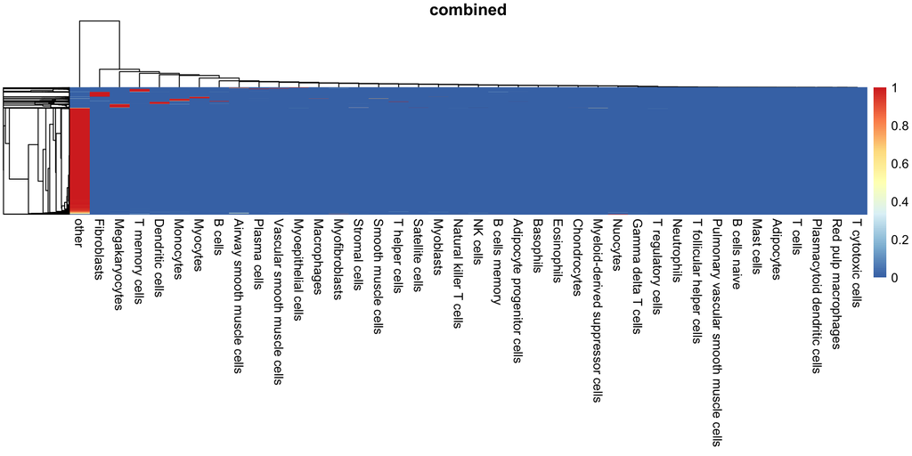

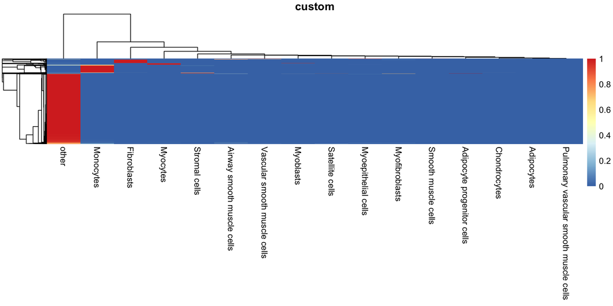

[figure not shown]

```r
# heatmap of prediction scores
all_predictions |>
  purrr::imap(\(prediction_mtx, organ_type){

    prediction_mtx |>
      dplyr::select(-barcode) |>
      as.matrix() |>
      pheatmap::pheatmap(show_rownames = FALSE,
                         main = organ_type)

  })
```

The main conclusion after looking at this is that regardless of the marker gene set, most cells get classified as “other”

## Comparison between marker gene sets

Here we directly compare the annotations between different marker gene sets and the submitter annotations.

```r
# add celltypes to processed sce
processed_sce$combined_assignments <- all_assignments$combined$celltype
processed_sce$custom_assignments <- all_assignments$custom$celltype
processed_sce$muscle_only_assignments <- all_assignments$muscle_only$celltype
```

```r
# extract coldata for easy plotting
coldata_df <- colData(processed_sce) |>
  as.data.frame() |>
  dplyr::select(barcode, celltype, combined_assignments, custom_assignments, muscle_only_assignments) |>
  # classify cells as tumor or normal
  dplyr::mutate(cell_category = dplyr::if_else(stringr::str_detect(celltype, "Tumor"), "Tumor", celltype),
                # remove sub states of myoblast/mesoderm/myocyte
                broad_celltype = stringr::str_remove(celltype, "-\\w$"))
```

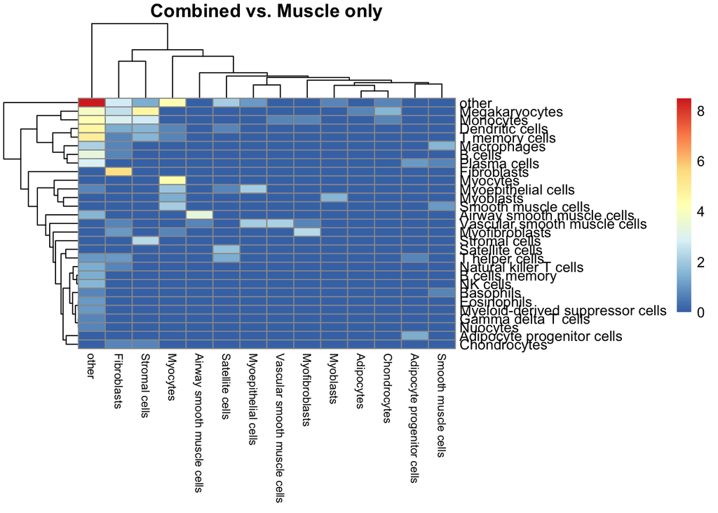

```r
compare_refs_heatmap(original_assignment = coldata_df$combined_assignments,
                     cell_assign = coldata_df$muscle_only_assignments,
                     title = "Combined vs. Muscle only")
```

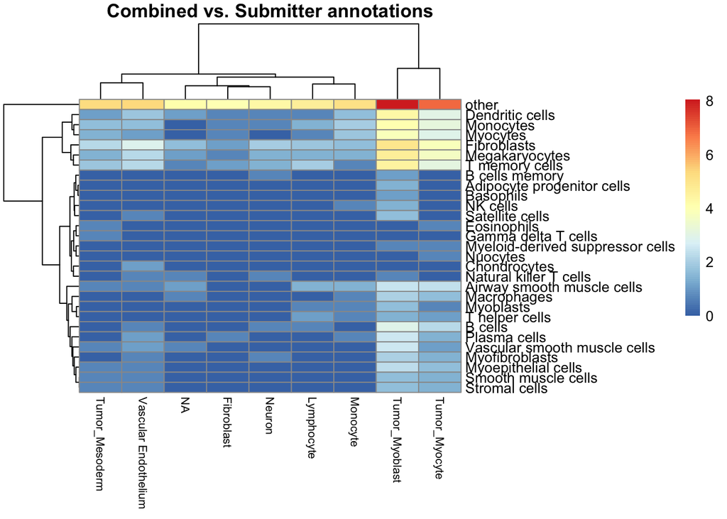

```r
compare_refs_heatmap(original_assignment = coldata_df$combined_assignments,
                     cell_assign = coldata_df$broad_celltype,
                     title = "Combined vs. Submitter annotations")
```

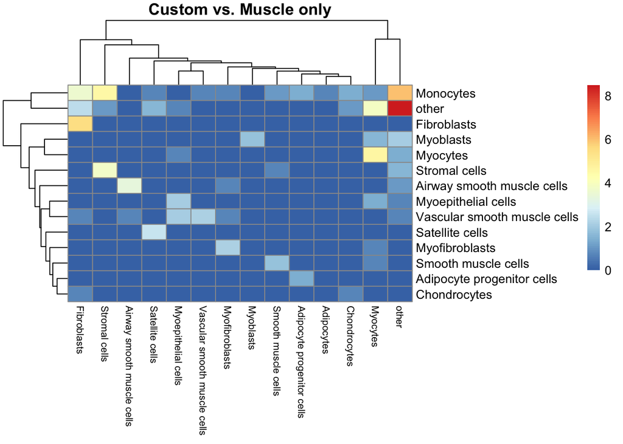

```r
compare_refs_heatmap(original_assignment = coldata_df$custom_assignments,
                     cell_assign = coldata_df$muscle_only_assignments,
                     title = "Custom vs. Muscle only")
```

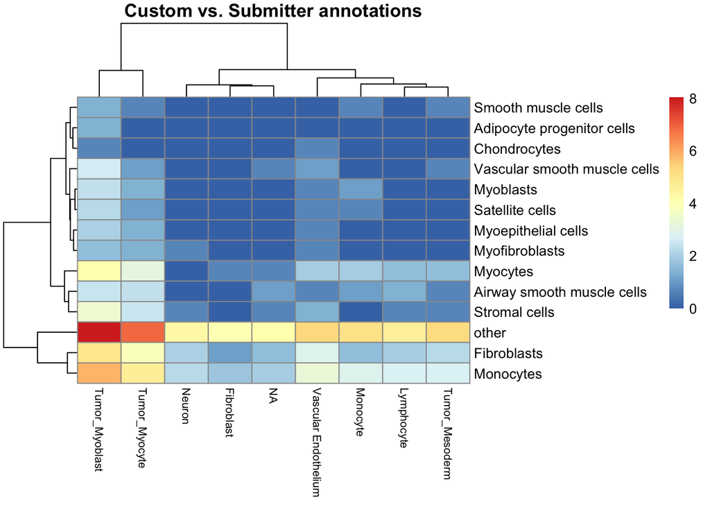

```r
compare_refs_heatmap(original_assignment = coldata_df$custom_assignments,
                     cell_assign = coldata_df$broad_celltype,
                     title = "Custom vs. Submitter annotations")
```

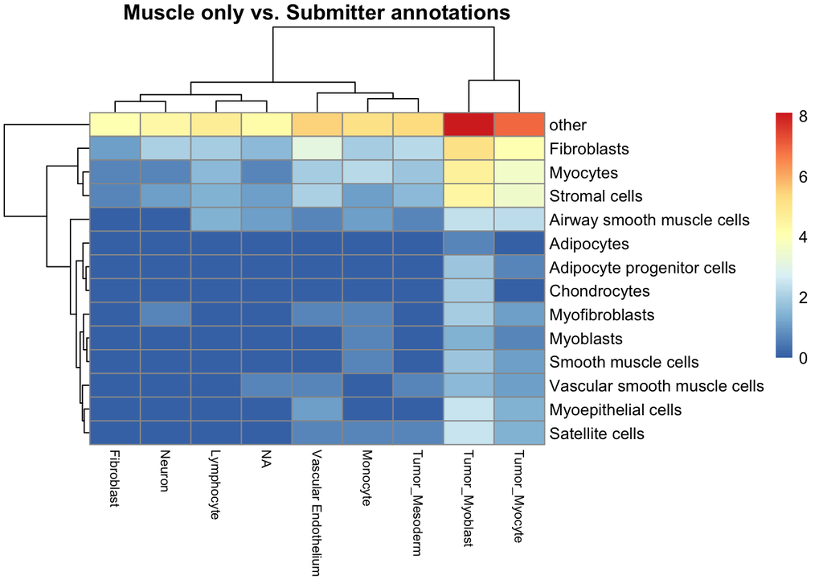

```r
compare_refs_heatmap(original_assignment = coldata_df$muscle_only_assignments,
                     cell_assign = coldata_df$broad_celltype,
                     title = "Muscle only vs. Submitter annotations")
```

## Conclusions

- Regardless of which combination of cell types we choose from `PanglaoDB` most of the cells get categorized as “other” for this sample. One thing to note is that when using `SingleR` we are able to assign cells to `muscle cells` and `skeletal muscle cells`. Although the assignments from `SingleR` (see `singler-rms-comparison.Rmd`) don’t completely line up with the submitter annotations, identifying cells as muscle cells rather than labeling most of them as “other” does seem more informative to me.
- The more marker genes you have the more time `CellAssign` takes. We already knew this, but this was a new record. It took ~ 2 hours to run the immune + connective tissue with 8 cpus.
- I don’t think adding in the immune system really helped that much. It just made it take longer and then assigned cells to immune cells that were not previously identified in our dataset. Maybe we don’t need to use multiple organs?